# Exercicio Computacional 1 e 2

Exercicios Conceituais

## 1 - D

## 2 - C

## 3 - C

## 4 - C

## 5 - A

## 6 - C

## 7 - C

Carregando dependências

```r
library(caret)
library(ROCR)
library(e1071)
library(datasets)
library(skimr)
library(dplyr)
```

```r
library(varhandle)
library(corrplot)
library(ggplot2)
library(MASS)
library(ROCR)
library(e1071)
```

## 1. Exercício 1 (Regressão Logística)

Considere o conjunto de dados iris, amplamente conhecido e usado como exemplo em diversos livros de aprendizagem de máquina. Esse conjunto já vem incorporado em diversos pacotes das linguagens R e Python, de acordo com Linguagem R: library(datasets) Linguagem Python: from sklearn import datasets A partir do conjunto de dados carregado capture somente os dados relacionados com a classe virginica, que consiste em uma espécie de uma planta (flor). O objetivo desse exercício é construir um classificador binário a partir de um modelo de regressão logística, permitindo verificar se uma espécie a ser testada é ou não do tipo virginica. Isso significa que um pré-processamento deve ser realizado sobre o dataset iris a fim de obtermos apenas duas classes (e.g., 0 -> não é virginica e 1 -> é virginica). As variáveis explanatórias desse conhecido dataset são: • Petal.Length: comprimento da pétala da flor • Petal.Width: largura da pétala da flor • Sepal.Length: comprimento da sépala da flor • Sepal.Width: largura da sépala da flor • Questões Avaliativas > 1) Realize o pré-processamento necessário para extração dos dados relacionados à classe virginica.

```r
dataset = iris

# Processando as classes para sua binarização do problema de classificação
# Objetivo: capturar as classes de interesse e atribuir 0 ou 1 para a espécie considerada no dataset
binary_species <- to.dummy(iris$Species, "species")
binary_species <- as.data.frame(binary_species)
unique(binary_species)
```

|  | species.setosa | species.versicolor | species.virginica |
| --- | --- | --- | --- |
| 1 | 1 | 0 | 0 |
| 51 | 0 | 1 | 0 |
| 101 | 0 | 0 | 1 |

```r
Species = binary_species$species.virginica
dataset = data.frame(dataset[,1:4],Species)

str(dataset)
```

```
## 'data.frame':    150 obs. of  5 variables:
##  $ Sepal.Length: num  5.1 4.9 4.7 4.6 5 5.4 4.6 5 4.4 4.9 ...
##  $ Sepal.Width : num  3.5 3 3.2 3.1 3.6 3.9 3.4 3.4 2.9 3.1 ...
##  $ Petal.Length: num  1.4 1.4 1.3 1.5 1.4 1.7 1.4 1.5 1.4 1.5 ...
##  $ Petal.Width : num  0.2 0.2 0.2 0.2 0.2 0.4 0.3 0.2 0.2 0.1 ...
##  $ Species     : num  0 0 0 0 0 0 0 0 0 0 ...
```

```r
# Atribuição do tipo fator à coluna especies (species) do dataset
cols <- c("Species")
dataset[cols] <- lapply(dataset[cols], factor)  ## as.factor() poderia ser usado

species_iris <- dataset$Species
species_iris
```

```
##   [1] 0 0 0 0 0 0 0 0 0 0 0 0 0 0 0 0 0 0 0 0 0 0 0 0 0 0 0 0 0 0 0 0 0 0 0 0 0
##  [38] 0 0 0 0 0 0 0 0 0 0 0 0 0 0 0 0 0 0 0 0 0 0 0 0 0 0 0 0 0 0 0 0 0 0 0 0 0
##  [75] 0 0 0 0 0 0 0 0 0 0 0 0 0 0 0 0 0 0 0 0 0 0 0 0 0 0 1 1 1 1 1 1 1 1 1 1 1
## [112] 1 1 1 1 1 1 1 1 1 1 1 1 1 1 1 1 1 1 1 1 1 1 1 1 1 1 1 1 1 1 1 1 1 1 1 1 1
## [149] 1 1
## Levels: 0 1
```

```r
unique(species_iris)
```

```
## [1] 0 1
## Levels: 0 1
```

```r
size_dataset = dim(dataset)
```

> 2. Faça a análise de dados das variáveis explanatórias para o conjunto de dados.

```r
summary(iris)
```

```
##   Sepal.Length    Sepal.Width     Petal.Length    Petal.Width
##  Min.   :4.300   Min.   :2.000   Min.   :1.000   Min.   :0.100
##  1st Qu.:5.100   1st Qu.:2.800   1st Qu.:1.600   1st Qu.:0.300
##  Median :5.800   Median :3.000   Median :4.350   Median :1.300
##  Mean   :5.843   Mean   :3.057   Mean   :3.758   Mean   :1.199
##  3rd Qu.:6.400   3rd Qu.:3.300   3rd Qu.:5.100   3rd Qu.:1.800
##  Max.   :7.900   Max.   :4.400   Max.   :6.900   Max.   :2.500
##        Species
##  setosa    :50
##  versicolor:50
##  virginica :50
##
##
##
```

Covariancia entre as variaveis.

```r
cov(iris[, 1:4])
```

```
##              Sepal.Length Sepal.Width Petal.Length Petal.Width
## Sepal.Length    0.6856935  -0.0424340    1.2743154   0.5162707
## Sepal.Width    -0.0424340   0.1899794   -0.3296564  -0.1216394
## Petal.Length    1.2743154  -0.3296564    3.1162779   1.2956094
## Petal.Width     0.5162707  -0.1216394    1.2956094   0.5810063
```

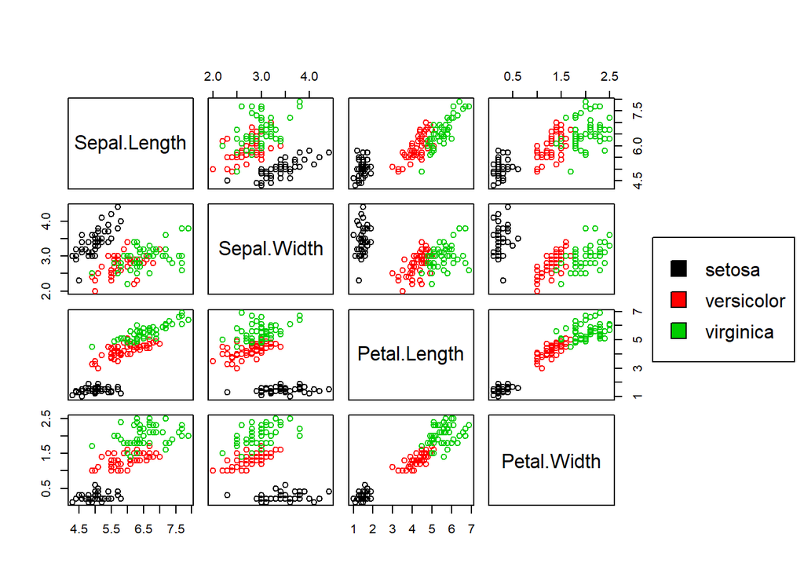

```r
pairs(iris[,1:4],col=iris[,5],oma=c(4,4,6,12))
par(xpd=TRUE)
legend(0.85,0.6, as.vector(unique(iris$Species)),fill=c(1,2,3))
```

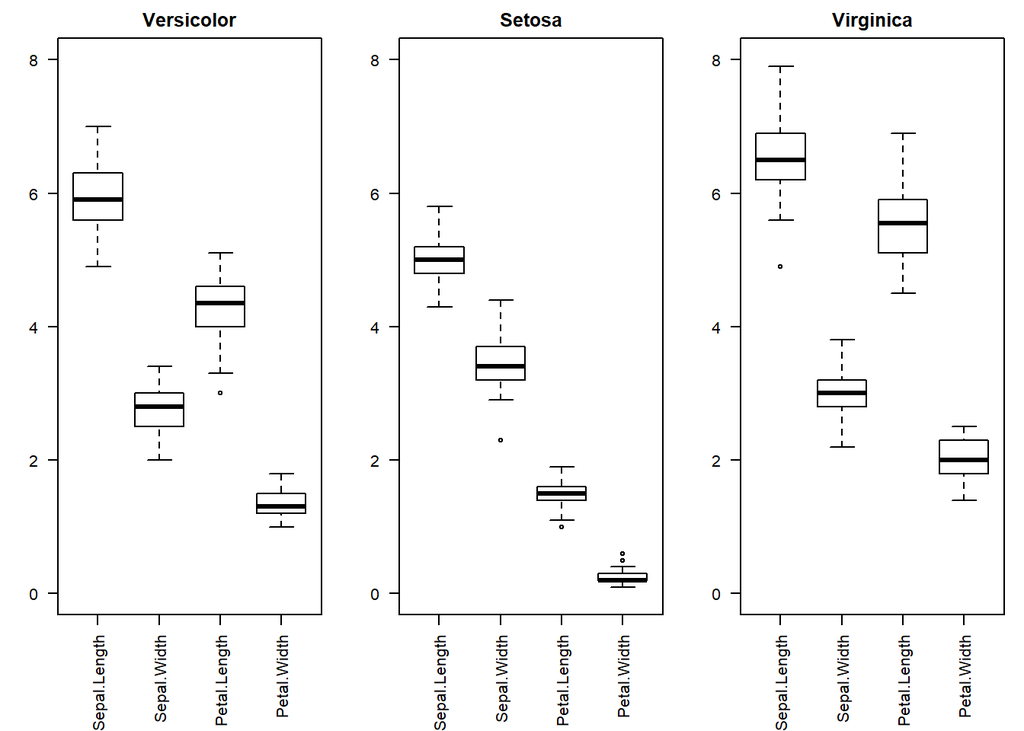

```r
irisVer <- subset(iris, Species == "versicolor")
irisSet <- subset(iris, Species == "setosa")
irisVir <- subset(iris, Species == "virginica")
par(mfrow=c(1,3),mar=c(6,3,2,1))
boxplot(irisVer[,1:4], main="Versicolor",ylim = c(0,8),las=2)
boxplot(irisSet[,1:4], main="Setosa",ylim = c(0,8),las=2)
boxplot(irisVir[,1:4], main="Virginica",ylim = c(0,8),las=2)
```

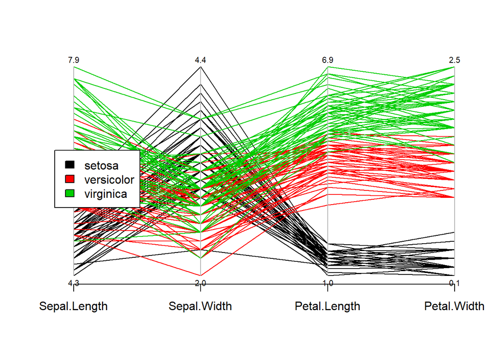

```r
parcoord(iris[,1:4], col=iris[,5],var.label=TRUE,oma=c(4,4,6,12))
par(xpd=TRUE)
legend(0.85,0.6, as.vector(unique(iris$Species)),fill=c(1,2,3))
```

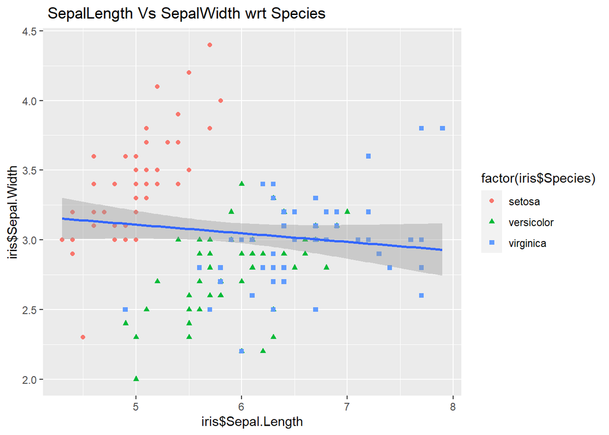

```r
g <- ggplot(iris, aes(x = iris$Sepal.Length, y = iris$Sepal.Width))
g <- g + geom_point(aes(shape = factor(iris$Species), colour = factor(iris$Species)))
g <- g + ggtitle (" SepalLength Vs SepalWidth wrt Species" )
g <- g + stat_smooth(method= lm)
g
```

> 3. Realize a divisão do conjunto de treino e teste em 90/10.

```r
set.seed(50)
species_iris <- dataset$Species
species_iris
```

```
##   [1] 0 0 0 0 0 0 0 0 0 0 0 0 0 0 0 0 0 0 0 0 0 0 0 0 0 0 0 0 0 0 0 0 0 0 0 0 0
##  [38] 0 0 0 0 0 0 0 0 0 0 0 0 0 0 0 0 0 0 0 0 0 0 0 0 0 0 0 0 0 0 0 0 0 0 0 0 0
##  [75] 0 0 0 0 0 0 0 0 0 0 0 0 0 0 0 0 0 0 0 0 0 0 0 0 0 0 1 1 1 1 1 1 1 1 1 1 1
## [112] 1 1 1 1 1 1 1 1 1 1 1 1 1 1 1 1 1 1 1 1 1 1 1 1 1 1 1 1 1 1 1 1 1 1 1 1 1
## [149] 1 1
## Levels: 0 1
```

```r
unique(species_iris)
```

```
## [1] 0 1
## Levels: 0 1
```

```r
# É fundamental checar as dimensões (tamanhos) dos datasets para o split (divisão)
# a função dim nos informa a quantidade de linhas e colunas do dataset
size_dataset = dim(dataset)

# Divisão - split de dataset em treino e teste (p é a porcentagem relacionada ao treinamento)
indices_treinamento <- createDataPartition(dataset$Species, p = 0.9, list = FALSE)

# Agora, vamos usar os �?ndices de treinamento para gerar o conjunto de dados de treinamento
dados_treinamento <-dataset[indices_treinamento,]
# Em seguida, podemos acessar diretamente o conjunto de teste
dados_teste <- dataset[-indices_treinamento,]
```

> 4. Para reprodução dos resultados use o set.seed(12).

```r
set.seed(12)
```

> 5. Forneça visualizações de dispersão e densidades das variáveis explanatórias de treino e as classes.

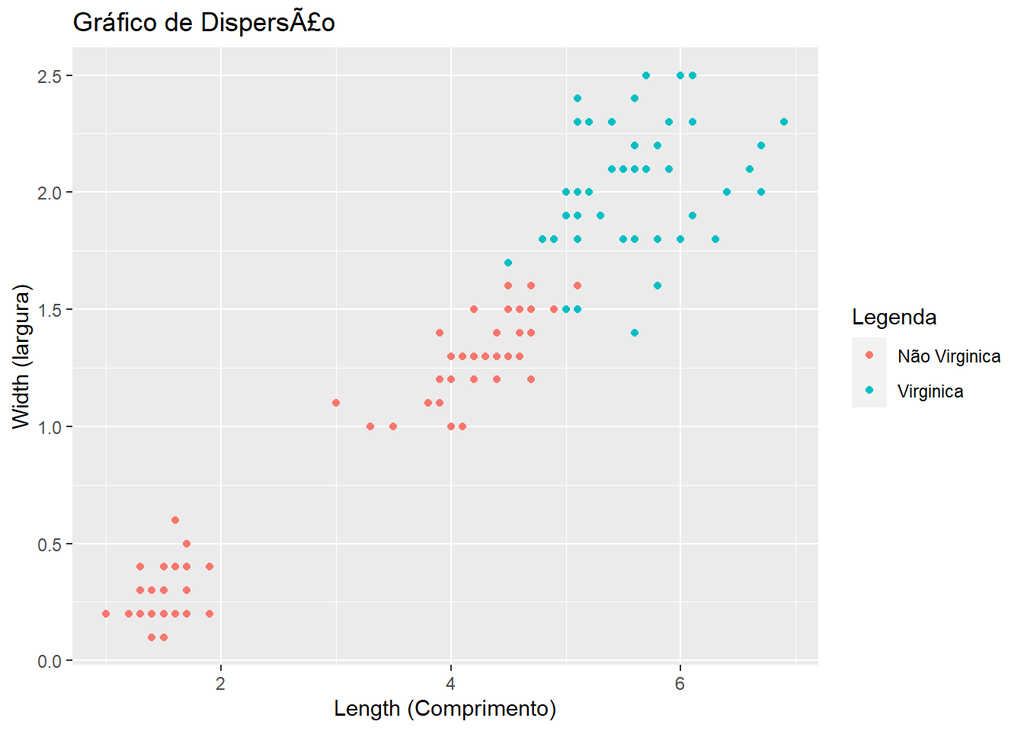

```r
# Gráfico de Dispersão com ggplot
ggplot(dados_treinamento, aes(x = dados_treinamento$Petal.Length, y = dados_treinamento$Petal.Width, color=Species)) +
  geom_point() +
  scale_color_discrete(name = "Legenda", labels = c("Não Virginica","Virginica"))+
  ylab('Width (largura)') +
  xlab('Length (Comprimento)') +
  ggtitle("Gráfico de DispersÃ£o")
```

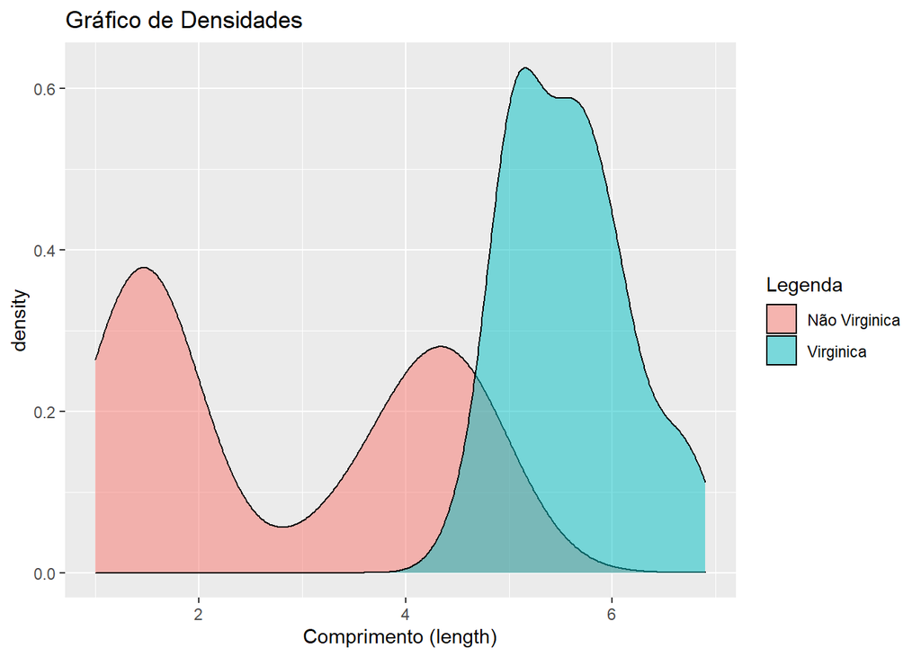

```r
ggplot(data = dados_treinamento, aes(x=dados_treinamento$Petal.Length, fill= Species)) +
  geom_density(alpha=.5) +
  xlab('Comprimento (length)') +
  scale_fill_discrete(name = "Legenda", labels = c("Não Virginica","Virginica")) +
  ggtitle("Gráfico de Densidades")
```

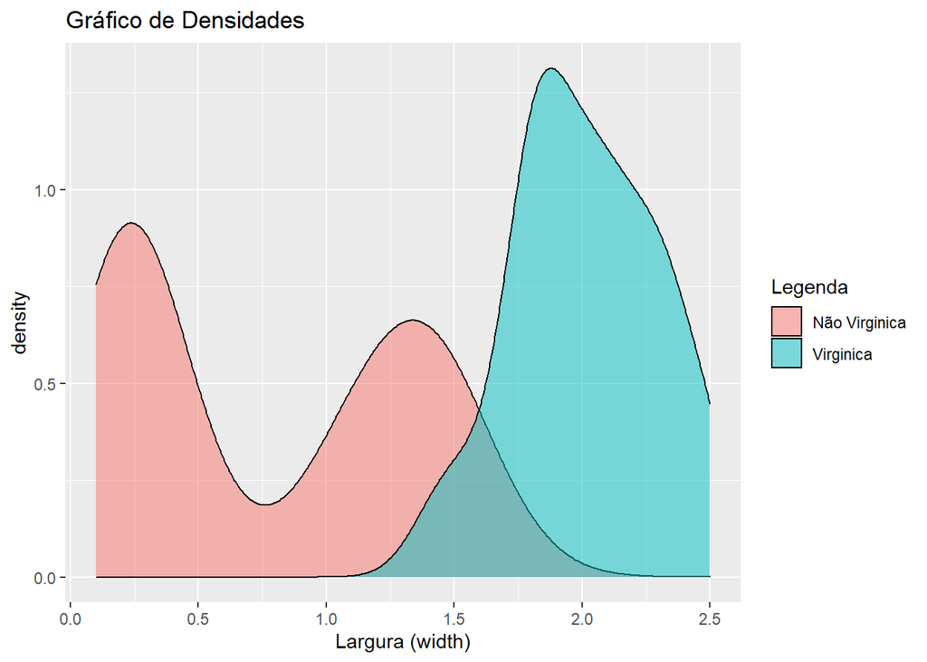

```r
ggplot(data = dados_treinamento, aes(x=dados_treinamento$Petal.Width, fill= Species)) +
  geom_density(alpha=.5) +
  xlab('Largura (width)') +
  scale_fill_discrete(name = "Legenda", labels = c("Não Virginica","Virginica")) +
  ggtitle("Gráfico de Densidades")
```

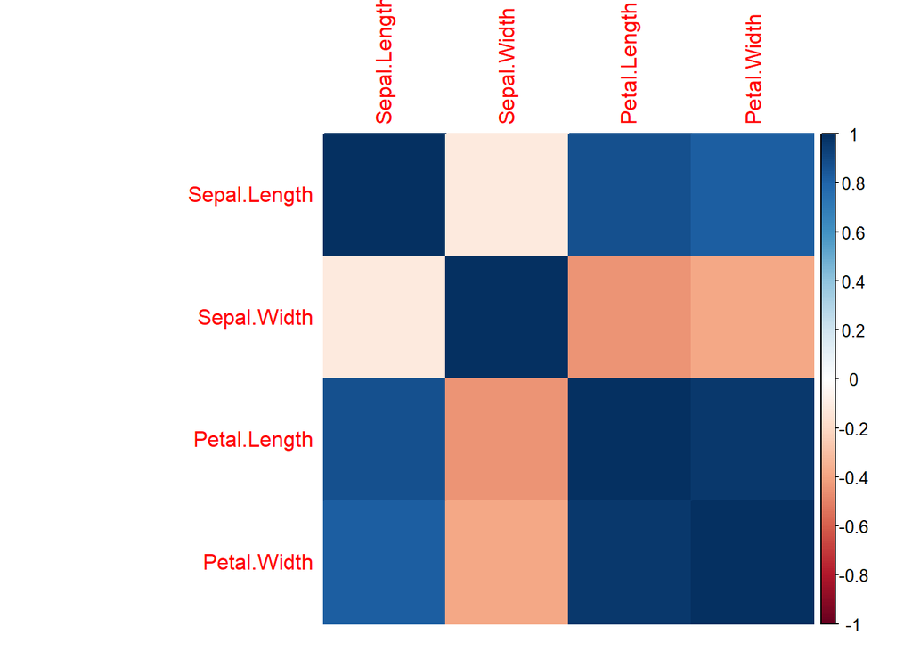

```r
feature_dataframe    = dados_treinamento[,1:4]
matrix_corr_features = cor(feature_dataframe)
corrplot(matrix_corr_features, method = 'color')
```

> 6. Construa e treine o modelo preditivo de ML baseado em regressão logística.

```r
equation <- " Species ~ ."
equation <- as.formula(equation)

modelo_ML_logistic <- glm(equation, data = dados_treinamento, family = 'binomial')
```

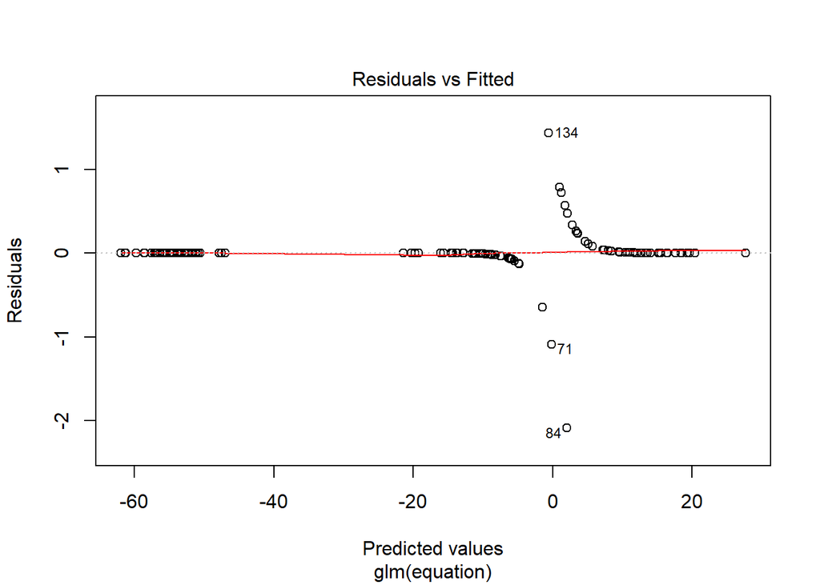

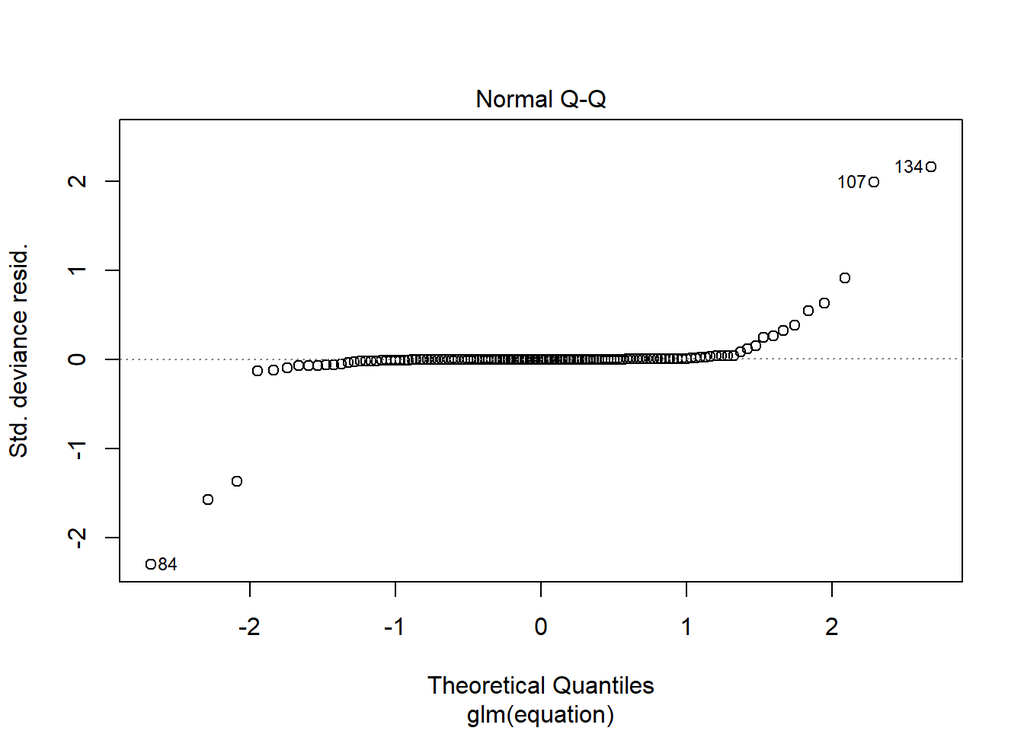

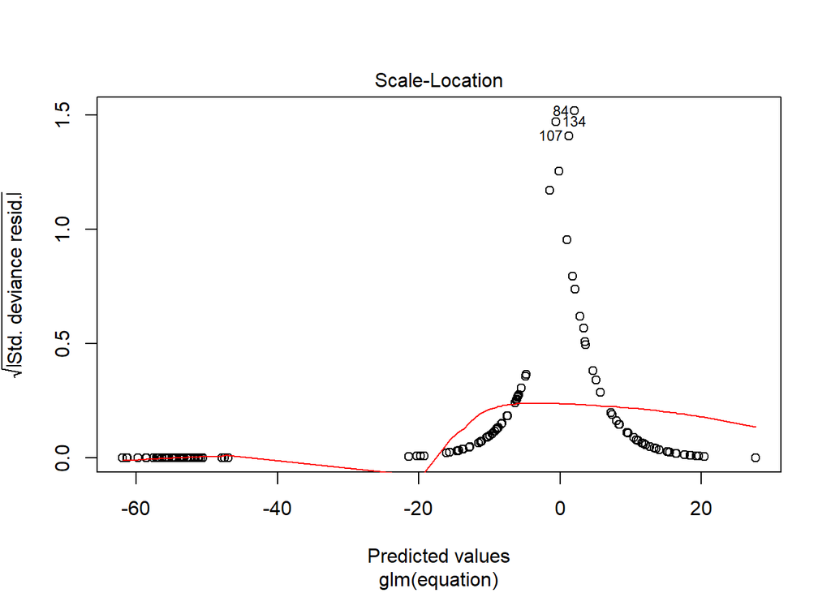

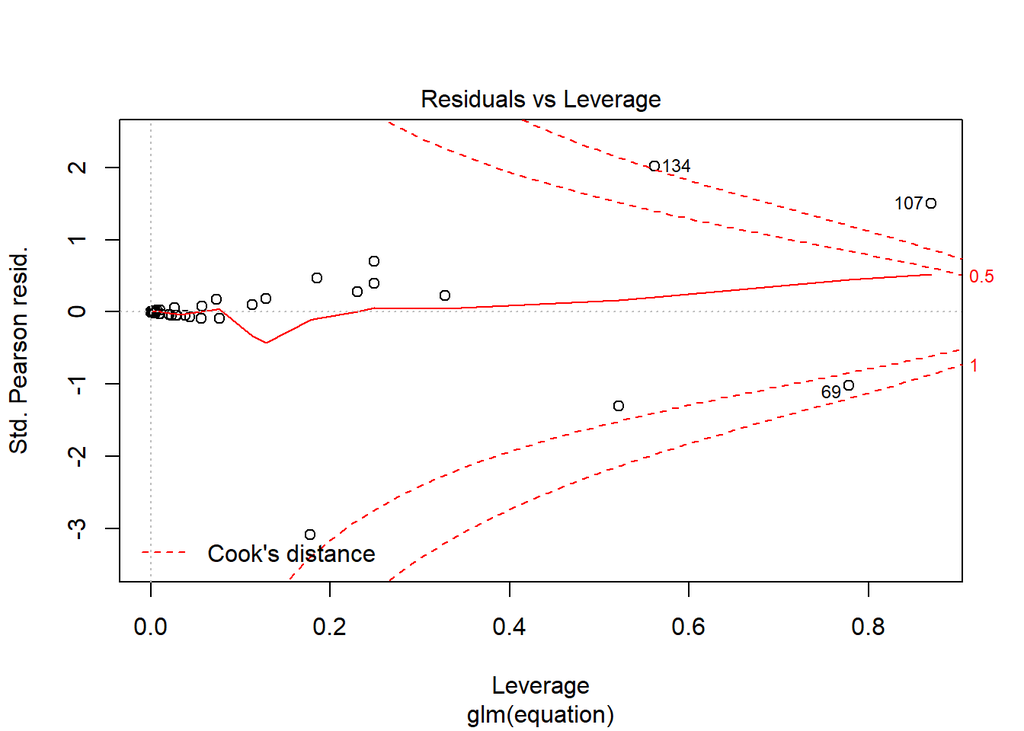

```r
plot(modelo_ML_logistic)
```

> 7. Faça a síntese do modelo e interprete os seus resultados.

```r
summary(modelo_ML_logistic)
```

```
##
## Call:
## glm(formula = equation, family = "binomial", data = dados_treinamento)
##
## Deviance Residuals:
##      Min        1Q    Median        3Q       Max
## -2.08925  -0.00125   0.00000   0.00065   1.43190
##
## Coefficients:
##              Estimate Std. Error z value Pr(>|z|)
## (Intercept)   -43.189     25.209  -1.713   0.0867 .
## Sepal.Length   -0.981      2.363  -0.415   0.6780
## Sepal.Width    -6.581      4.327  -1.521   0.1283
## Petal.Length    8.206      4.356   1.884   0.0596 .
## Petal.Width    16.912      9.564   1.768   0.0770 .
## ---
## Signif. codes:  0 '***' 0.001 '**' 0.01 '*' 0.05 '.' 0.1 ' ' 1
##
## (Dispersion parameter for binomial family taken to be 1)
##
##     Null deviance: 171.859  on 134  degrees of freedom
## Residual deviance:  10.125  on 130  degrees of freedom
## AIC: 20.125
##
## Number of Fisher Scoring iterations: 12
```

> 8. Encontre as variáveis explanatórias mais relevantes para o modelo.

```r
varImpl <- varImp(modelo_ML_logistic)
print(varImpl)
```

```
##                Overall
## Sepal.Length 0.4151897
## Sepal.Width  1.5208925
## Petal.Length 1.8837118
## Petal.Width  1.7682941
```

> 9. Faça as predições para os dados de teste e avalie os resultados

```r
previsao_teste <- predict(modelo_ML_logistic, dados_teste, type="response")
previsao_teste <- round(as.numeric(previsao_teste))
previsao_teste <- as.factor(previsao_teste)

dados_teste_fatores = as.factor(dados_teste$Species)
previsao_teste_data <- data.frame(previsao_teste, dados_teste_fatores)
confusionMatrix(data = previsao_teste, reference = dados_teste_fatores, positive = "1")
```

```
## Confusion Matrix and Statistics
##
##           Reference
## Prediction 0 1
##          0 9 0
##          1 1 5
##
##                Accuracy : 0.9333
##                  95% CI : (0.6805, 0.9983)
##     No Information Rate : 0.6667
##     P-Value [Acc > NIR] : 0.01941
##
##                   Kappa : 0.8571
##
##  Mcnemar's Test P-Value : 1.00000
##
##             Sensitivity : 1.0000
##             Specificity : 0.9000
##          Pos Pred Value : 0.8333
##          Neg Pred Value : 1.0000
##              Prevalence : 0.3333
##          Detection Rate : 0.3333
##    Detection Prevalence : 0.4000
##       Balanced Accuracy : 0.9500
##
##        'Positive' Class : 1
##
```

```r
# Cômputo da acurácia
accuracy <- mean(dados_teste_fatores == previsao_teste)
accuracy
```

```
## [1] 0.9333333
```

```r
previsao_teste_data
```

| previsao_teste | dados_teste_fatores |
| --- | --- |
| 0 | 0 |
| 0 | 0 |
| 0 | 0 |
| 0 | 0 |
| 0 | 0 |
| 0 | 0 |
| 1 | 0 |
| 0 | 0 |
| 0 | 0 |
| 0 | 0 |

[output cut: 5 more lines]

> 10. A partir dos novos dados de entrada colocados abaixo, realize as classificações com o modelo

```r
flor1 <- data.frame(Sepal.Length=6.4, Sepal.Width=2.8, Petal.Length=4.6, Petal.Width=1.8)
flor2 <- data.frame(Sepal.Length=6.3, Sepal.Width=2.5, Petal.Length=4.1, Petal.Width=1.7)

pred_flor1 <- predict(modelo_ML_logistic, flor1, type = 'response')
pred_flor2 <- predict(modelo_ML_logistic, flor2, type = 'response')
pred_flor1
```

```
##         1
## 0.5724985
```

```r
pred_flor2
```

```
##          1
## 0.03138851
```

```r
confusionMatrix(data = previsao_teste, reference = dados_teste_fatores, positive = "1")
```

```
## Confusion Matrix and Statistics
##
##           Reference
## Prediction 0 1
##          0 9 0
##          1 1 5
##
##                Accuracy : 0.9333
##                  95% CI : (0.6805, 0.9983)
##     No Information Rate : 0.6667
##     P-Value [Acc > NIR] : 0.01941
##
##                   Kappa : 0.8571
##
##  Mcnemar's Test P-Value : 1.00000
##
##             Sensitivity : 1.0000
##             Specificity : 0.9000
##          Pos Pred Value : 0.8333
##          Neg Pred Value : 1.0000
##              Prevalence : 0.3333
##          Detection Rate : 0.3333
##    Detection Prevalence : 0.4000
##       Balanced Accuracy : 0.9500
##
##        'Positive' Class : 1
##
```

## Exercicio 3 - Exercício 3 (Regressão Logística)

Uma instituição financeira nos forneceu um conjunto de dados relacionados à créditos financeiros presentes no banco de dados da instituição. A instituição está trabalhando em um projeto de ciência de dados para previsão de risco de crédito. Nós iremos participar de uma fase específica desse projeto com o objetivo de construir um classificador, que possa auxiliar na análise de risco de crédito de diversos clientes da instituição. O modelo de ML (i.e., classificador) deve prever se um determinado cliente deve ou não receber créditos de produtos financeiros ofertados pela instituição. Isso significa que teremos acesso a um conjunto de dados com informações diversas sobre inúmeros clientes da instituição. O conjunto de dados consiste em vinte (20) variáveis explanatórias que consistem em informações diversas sobre os clientes incluindo: duração e tamanho do crédito, indicadores de saldo e operações financeiras, além de dados dos clientes como idade, dependentes, emprego e até contatos como telefone. Tais informações são apresentadas com codificação que são processadas pela instituição para posteriores interpretações. Com isso, nossa tarefa consiste em lidar com os dados codificados e a variável de saída credit.rating, que indica o estado de aprovação (1) ou desaprovação (0) de crédito para cada dados de treinamento (registro) do dataset. Os pacotes listados abaixo serão fundamentais para as questões avaliativas: • library(caret) • library(ROCR) • library(e1071)

> 1. Realize a importação do arquivo .csv fornecido para o RStudio

```r
dataset_credito <- read.csv('credit_dataset.csv', sep = ',')
```

> 2. Faça a análise exploratória do dataset e verifique:

```r
summary(dataset_credito)
```

```
##  credit.rating account.balance credit.duration.months
##  Min.   :0.0   Min.   :1.000   Min.   : 4.0
##  1st Qu.:0.0   1st Qu.:1.000   1st Qu.:12.0
##  Median :1.0   Median :2.000   Median :18.0
##  Mean   :0.7   Mean   :2.183   Mean   :20.9
##  3rd Qu.:1.0   3rd Qu.:3.000   3rd Qu.:24.0
##  Max.   :1.0   Max.   :3.000   Max.   :72.0
##  previous.credit.payment.status credit.purpose  credit.amount      savings
##  Min.   :1.000                  Min.   :1.000   Min.   :  250   Min.   :1.000
##  1st Qu.:2.000                  1st Qu.:2.000   1st Qu.: 1366   1st Qu.:1.000
##  Median :2.000                  Median :3.000   Median : 2320   Median :1.000
##  Mean   :2.292                  Mean   :2.965   Mean   : 3271   Mean   :1.874
##  3rd Qu.:3.000                  3rd Qu.:4.000   3rd Qu.: 3972   3rd Qu.:3.000
##  Max.   :3.000                  Max.   :4.000   Max.   :18424   Max.   :4.000
##  employment.duration installment.rate marital.status    guarantor
##  Min.   :1.000       Min.   :1.000    Min.   :1.000   Min.   :1.000
##  1st Qu.:2.000       1st Qu.:2.000    1st Qu.:1.000   1st Qu.:1.000
##  Median :2.000       Median :3.000    Median :3.000   Median :1.000
##  Mean   :2.446       Mean   :2.973    Mean   :2.372   Mean   :1.093
##  3rd Qu.:4.000       3rd Qu.:4.000    3rd Qu.:3.000   3rd Qu.:1.000
##  Max.   :4.000       Max.   :4.000    Max.   :4.000   Max.   :2.000
##  residence.duration current.assets       age        other.credits
##  Min.   :1.000      Min.   :1.000   Min.   :19.00   Min.   :1.000
##  1st Qu.:2.000      1st Qu.:1.000   1st Qu.:27.00   1st Qu.:2.000
##  Median :3.000      Median :2.000   Median :33.00   Median :2.000
##  Mean   :2.845      Mean   :2.358   Mean   :35.54   Mean   :1.814
##  3rd Qu.:4.000      3rd Qu.:3.000   3rd Qu.:42.00   3rd Qu.:2.000
##  Max.   :4.000      Max.   :4.000   Max.   :75.00   Max.   :2.000
##  apartment.type   bank.credits     occupation      dependents
##  Min.   :1.000   Min.   :1.000   Min.   :1.000   Min.   :1.000
##  1st Qu.:2.000   1st Qu.:1.000   1st Qu.:3.000   1st Qu.:1.000
##  Median :2.000   Median :1.000   Median :3.000   Median :1.000
##  Mean   :1.928   Mean   :1.367   Mean   :2.904   Mean   :1.155
##  3rd Qu.:2.000   3rd Qu.:2.000   3rd Qu.:3.000   3rd Qu.:1.000
##  Max.   :3.000   Max.   :2.000   Max.   :4.000   Max.   :2.000
##    telephone     foreign.worker
##  Min.   :1.000   Min.   :1.000
##  1st Qu.:1.000   1st Qu.:1.000
##  Median :1.000   Median :1.000
##  Mean   :1.404   Mean   :1.037
##  3rd Qu.:2.000   3rd Qu.:1.000
##  Max.   :2.000   Max.   :2.000
```

```r
str(dataset_credito)
```

```
## 'data.frame':    1000 obs. of  21 variables:
##  $ credit.rating                 : int  1 1 1 1 1 1 1 1 1 1 ...
##  $ account.balance               : int  1 1 2 1 1 1 1 1 3 2 ...
##  $ credit.duration.months        : int  18 9 12 12 12 10 8 6 18 24 ...
##  $ previous.credit.payment.status: int  3 3 2 3 3 3 3 3 3 2 ...
##  $ credit.purpose                : int  2 4 4 4 4 4 4 4 3 3 ...
##  $ credit.amount                 : int  1049 2799 841 2122 2171 2241 3398 1361 1098 3758 ...
##  $ savings                       : int  1 1 2 1 1 1 1 1 1 3 ...
##  $ employment.duration           : int  1 2 3 2 2 1 3 1 1 1 ...
##  $ installment.rate              : int  4 2 2 3 4 1 1 2 4 1 ...
##  $ marital.status                : int  1 3 1 3 3 3 3 3 1 1 ...
##  $ guarantor                     : int  1 1 1 1 1 1 1 1 1 1 ...
##  $ residence.duration            : int  4 2 4 2 4 3 4 4 4 4 ...
##  $ current.assets                : int  2 1 1 1 2 1 1 1 3 4 ...
##  $ age                           : int  21 36 23 39 38 48 39 40 65 23 ...
##  $ other.credits                 : int  2 2 2 2 1 2 2 2 2 2 ...
##  $ apartment.type                : int  1 1 1 1 2 1 2 2 2 1 ...
##  $ bank.credits                  : int  1 2 1 2 2 2 2 1 2 1 ...
##  $ occupation                    : int  3 3 2 2 2 2 2 2 1 1 ...
##  $ dependents                    : int  1 2 1 2 1 2 1 2 1 1 ...
##  $ telephone                     : int  1 1 1 1 1 1 1 1 1 1 ...
##  $ foreign.worker                : int  1 1 1 2 2 2 2 2 1 1 ...
```

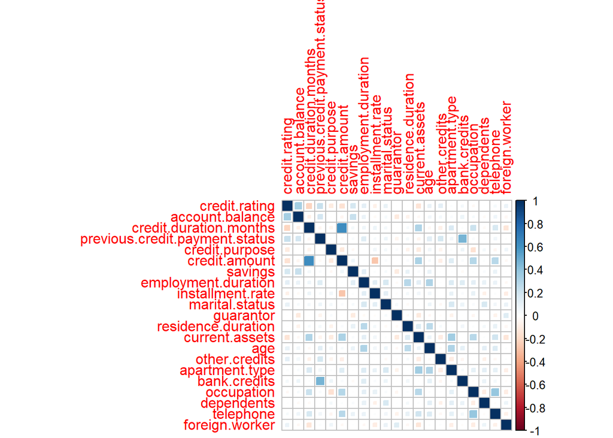

```r
M = cor(dataset_credito)
corrplot(M, method="square")
```

> 1. a necessidade de normalização dos dados Adicionando uma função para normalizar os dados
> 2. conversão para fatores Adicionando função para conversão de variáveis em fatores
> 3. Considerando o item 2) identifique quais são as variáveis numéricas e os fatores.

Variveis numéricas: “credit.duration.months”, “age”, “credit.amount”. Variaveis categoricas: ‘credit.rating’, ‘account.balance’, ‘previous.credit.payment.status’, ‘credit.purpose’, ‘savings’, ‘employment.duration’, ‘installment.rate’, ‘marital.status’, ‘guarantor’, ‘residence.duration’, ‘current.assets’, ‘other.credits’, ‘apartment.type’, ‘bank.credits’, ‘occupation’, ‘dependents’, ‘telephone’, ‘foreign.worker’

> Crie duas funções: para normalização e conversão em fatores.

```r
factor_conversion <- function(df , variaveis){
  # Loop para todas as variáveis
  for (variavel in variaveis){
  # Conversão para fator
  df[[variavel]] <- as.factor(df[[variavel]])
  }
  return(df)
}

normalizar_features <- function(df, variables){
  for (variable in variables){
    df[[variable]] <- scale(df[[variable]], center = T, scale = T)
  }
  return(df)
}

numeric_vars <- c("credit.duration.months", "age", "credit.amount")

# Aplicação da normalização das variáveis a partir se duas identificações
dataset_credito_normalizado <- normalizar_features(dataset_credito, numeric_vars)


categorical_vars <- c('credit.rating', 'account.balance', 'previous.credit.payment.status',
                      'credit.purpose', 'savings', 'employment.duration', 'installment.rate',
                      'marital.status', 'guarantor', 'residence.duration', 'current.assets',
                      'other.credits', 'apartment.type', 'bank.credits', 'occupation',
                      'dependents', 'telephone', 'foreign.worker')
dataset_credito_normalizado_factor <- factor_conversion(dataset_credito_normalizado, categorical_vars)
```

> 4. Realize a divisão do conjunto de treino e teste em 60/40.

```r
index_training = sample(1:nrow(dataset_credito_normalizado_factor), size = 0.6*nrow(dataset_credito_normalizado_factor))

training_data = dataset_credito_normalizado_factor[index_training,]
test_data     = dataset_credito_normalizado_factor[-index_training,]
test_features <- test_data[,-1]
test_target   <- test_data[,1]
```

```r
set.seed(90)
```

> 6. Construa e treine o modelo preditivo de ML baseado em regressão logística.

```r
equation <- "credit.rating ~ ."
equation <- as.formula(equation)
modelo_ML_logistic_1 <- glm(equation, data = training_data, family = "binomial")
modelo_ML_logistic_1
```

```
##
## Call:  glm(formula = equation, family = "binomial", data = training_data)
##
## Coefficients:
##                     (Intercept)                 account.balance2
##                         0.12559                          0.55363
##                account.balance3           credit.duration.months
##                         1.65037                         -0.19513
## previous.credit.payment.status2  previous.credit.payment.status3
##                         0.61980                          1.44361
##                 credit.purpose2                  credit.purpose3
##                        -0.97652                         -1.11762
##                 credit.purpose4                    credit.amount
##                        -1.57229                         -0.54020
##                        savings2                         savings3
##                        -0.05094                          0.89747
##                        savings4             employment.duration2
##                         0.86954                          0.30450
##            employment.duration3             employment.duration4
##                         0.73268                          0.14596
##               installment.rate2                installment.rate3
##                         0.11948                         -0.60156
##               installment.rate4                  marital.status3
##                        -1.13338                          0.31515
##                 marital.status4                       guarantor2
##                         0.30434                          0.82480
##             residence.duration2              residence.duration3
##                        -0.64603                         -0.38486
##             residence.duration4                  current.assets2
##                        -0.18523                         -0.05258
##                 current.assets3                  current.assets4
##                         0.21243                         -0.68483
##                             age                   other.credits2
##                         0.06280                          0.29074
##                 apartment.type2                  apartment.type3
##                         0.80058                          0.76894
##                   bank.credits2                      occupation2
##                        -0.50681                         -0.31568
##                     occupation3                      occupation4
##                        -0.20759                          0.58060
##                     dependents2                       telephone2
##                        -0.30598                          0.31172
##                 foreign.worker2
##                        16.33800
##
## Degrees of Freedom: 599 Total (i.e. Null);  561 Residual
## Null Deviance:       717.1
## Residual Deviance: 525.5     AIC: 603.5
```

> 7. Faça a síntese do modelo e interprete os seus resultados.

```r
summary(modelo_ML_logistic_1)
```

```
##
## Call:
## glm(formula = equation, family = "binomial", data = training_data)
##
## Deviance Residuals:
##     Min       1Q   Median       3Q      Max
## -2.5734  -0.6673   0.3844   0.7106   1.8848
##
## Coefficients:
##                                  Estimate Std. Error z value Pr(>|z|)
## (Intercept)                       0.12559    1.01769   0.123 0.901786
## account.balance2                  0.55363    0.28693   1.929 0.053670 .
## account.balance3                  1.65037    0.28495   5.792 6.96e-09 ***
## credit.duration.months           -0.19513    0.14634  -1.333 0.182405
## previous.credit.payment.status2   0.61980    0.37734   1.643 0.100472
## previous.credit.payment.status3   1.44361    0.41509   3.478 0.000506 ***
## credit.purpose2                  -0.97652    0.53258  -1.834 0.066721 .
## credit.purpose3                  -1.11762    0.50505  -2.213 0.026906 *
## credit.purpose4                  -1.57229    0.49056  -3.205 0.001350 **
## credit.amount                    -0.54020    0.16693  -3.236 0.001211 **
## savings2                         -0.05094    0.36225  -0.141 0.888160
## savings3                          0.89747    0.41297   2.173 0.029762 *
## savings4                          0.86954    0.35276   2.465 0.013703 *
## employment.duration2              0.30450    0.31552   0.965 0.334508
## employment.duration3              0.73268    0.37737   1.942 0.052194 .
## employment.duration4              0.14596    0.35953   0.406 0.684753
## installment.rate2                 0.11948    0.43015   0.278 0.781191
## installment.rate3                -0.60156    0.45659  -1.317 0.187674
## installment.rate4                -1.13338    0.40648  -2.788 0.005299 **
## marital.status3                   0.31515    0.27081   1.164 0.244535
## marital.status4                   0.30434    0.41475   0.734 0.463075
## guarantor2                        0.82480    0.40386   2.042 0.041122 *
## residence.duration2              -0.64603    0.39746  -1.625 0.104080
## residence.duration3              -0.38486    0.43012  -0.895 0.370909
## residence.duration4              -0.18523    0.39529  -0.469 0.639363
## current.assets2                  -0.05258    0.32573  -0.161 0.871773
## current.assets3                   0.21243    0.31972   0.664 0.506418
## current.assets4                  -0.68483    0.47349  -1.446 0.148085
## age                               0.06280    0.13586   0.462 0.643884
## other.credits2                    0.29074    0.28076   1.036 0.300408
## apartment.type2                   0.80058    0.32342   2.475 0.013309 *
## apartment.type3                   0.76894    0.56112   1.370 0.170570
## bank.credits2                    -0.50681    0.30809  -1.645 0.099964 .
## occupation2                      -0.31568    0.76902  -0.410 0.681448
## occupation3                      -0.20759    0.73007  -0.284 0.776151
## occupation4                       0.58060    0.77881   0.745 0.455971
## dependents2                      -0.30598    0.32391  -0.945 0.344846
## telephone2                        0.31172    0.26021   1.198 0.230932
## foreign.worker2                  16.33800  735.10852   0.022 0.982268
## ---
## Signif. codes:  0 '***' 0.001 '**' 0.01 '*' 0.05 '.' 0.1 ' ' 1
##
## (Dispersion parameter for binomial family taken to be 1)
##
##     Null deviance: 717.14  on 599  degrees of freedom
## Residual deviance: 525.46  on 561  degrees of freedom
## AIC: 603.46
##
## Number of Fisher Scoring iterations: 16
```

> 8. Faça as predições para os dados de teste e avalie os resultados com a matriz de confusão.

```r
previsao_teste <- predict(modelo_ML_logistic_1, test_data, type = 'response')
previsao_teste <- round(previsao_teste)
previsao_teste
```

```
##    4    5    6    7    9   11   14   15   20   21   22   23   26   27   33   37
##    1    1    1    1    1    0    1    1    1    0    1    0    1    0    1    1
##   39   40   41   46   47   51   52   55   56   57   59   60   63   64   67   68
##    1    1    1    0    1    1    1    1    1    1    1    1    1    1    1    1
##   70   76   78   80   83   87   89   90   92   94   95   97   98   99  101  102
##    1    1    1    1    1    1    1    1    1    1    1    1    1    1    1    0
##  106  107  110  114  116  117  120  130  132  135  142  149  150  153  156  160
##    1    1    1    1    0    1    1    1    1    1    1    1    1    1    1    1
##  166  169  171  172  177  178  179  182  190  193  195  197  200  205  207  208
##    1    1    1    0    1    1    1    1    1    1    1    1    1    1    1    1
##  209  215  220  221  225  227  229  230  232  234  235  237  238  240  249  251
##    0    1    1    1    1    0    1    0    1    1    1    1    0    1    1    1
##  252  254  256  258  261  265  272  275  280  282  284  285  286  293  297  298
##    1    1    1    1    1    1    1    1    1    1    1    0    1    1    1    1
##  301  307  311  312  315  316  317  318  319  324  330  331  332  337  340  341
```

[output cut: 35 more lines]

```r
previsao_teste_data <- data.frame(previsao_teste, test_target)
colnames(previsao_teste_data) <- c('Previsão','Target')
```

```r
cm_modelo_1 <- confusionMatrix(table(data = previsao_teste, reference = test_target), positive = "1")
cm_modelo_1
```

```
## Confusion Matrix and Statistics
##
##     reference
## data   0   1
##    0  56  22
##    1  73 249
##
##                Accuracy : 0.7625
##                  95% CI : (0.7177, 0.8034)
##     No Information Rate : 0.6775
##     P-Value [Acc > NIR] : 0.0001196
##
##                   Kappa : 0.3937
##
##  Mcnemar's Test P-Value : 2.899e-07
##
##             Sensitivity : 0.9188
##             Specificity : 0.4341
##          Pos Pred Value : 0.7733
##          Neg Pred Value : 0.7179
##              Prevalence : 0.6775
##          Detection Rate : 0.6225
##    Detection Prevalence : 0.8050
##       Balanced Accuracy : 0.6765
##
##        'Positive' Class : 1
##
```

> 9. Use a função varImp do pacote caret para descobrir as variáveis explanatórias mais relevantes para o modelo.

```r
feature_selection = varImp(modelo_ML_logistic_1, scale = TRUE)
# Visualização das variáveis explanatórias mais relevantes
feature_selection
```

|  | Overall |
| --- | --- |
| account.balance2 | 1.92948706 |
| account.balance3 | 5.79185166 |
| credit.duration.months | 1.33338661 |
| previous.credit.payment.status2 | 1.64256786 |
| previous.credit.payment.status3 | 3.47779989 |
| credit.purpose2 | 1.83354647 |
| credit.purpose3 | 2.21287532 |
| credit.purpose4 | 3.20508169 |
| credit.amount | 3.23618896 |
| savings2 | 0.14063269 |

[output cut: 28 more lines]

> 10. Obtenha a curva ROC do classificador antes da análise varImp.

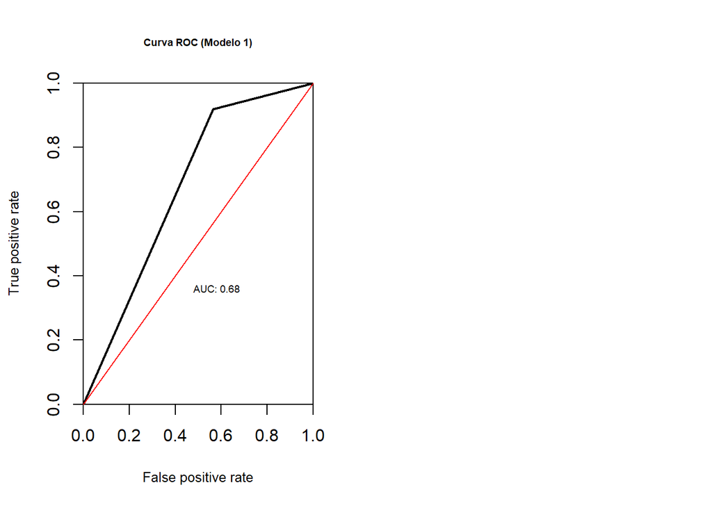

```r
# Função que podemos usar para plot da curva ROC
plot.roc.curve <- function(predictions, title.text){
  perf <- performance(predictions, "tpr", "fpr")
  plot(perf,col = "black",lty = 1, lwd = 2,
       main = title.text, cex.main = 0.6, cex.lab = 0.8,xaxs = "i", yaxs = "i")
  abline(0,1, col = "red")
  auc <- performance(predictions,"auc")
  auc <- unlist(slot(auc, "y.values"))
  auc <- round(auc,2)
  legend(0.4,0.4,legend = c(paste0("AUC: ",auc)), cex = 0.6, bty = "n", box.col = "white")
}

# Plot - quantidade de gráficos na paleta gráfica do R
par(mfrow = c(1, 2))
previsoes_finais_modelo_1 <- prediction(previsao_teste, test_target)
plot.roc.curve(previsoes_finais_modelo_1, title.text = "Curva ROC (Modelo 1)")
```

> 11. Obtenha a curva ROC do classificador após da análise com varImp.

```r
equation_nova <- "credit.rating ~ account.balance + credit.purpose + previous.credit.payment.status + savings + credit.duration.months"
equation_nova <- as.formula(equation_nova)

modelo_ML_logistic_2 <- glm(equation_nova, data = training_data, family = "binomial")
modelo_ML_logistic_2
```

```
##
## Call:  glm(formula = equation_nova, family = "binomial", data = training_data)
##
## Coefficients:
##                     (Intercept)                 account.balance2
##                         0.06456                          0.60944
##                account.balance3                  credit.purpose2
##                         1.68702                         -0.76888
##                 credit.purpose3                  credit.purpose4
##                        -0.96425                         -1.25701
## previous.credit.payment.status2  previous.credit.payment.status3
##                         0.84670                          1.20666
##                        savings2                         savings3
##                        -0.10738                          0.72575
##                        savings4           credit.duration.months
##                         0.54378                         -0.43277
##
## Degrees of Freedom: 599 Total (i.e. Null);  588 Residual
## Null Deviance:       717.1
## Residual Deviance: 591   AIC: 615
```

```r
summary(modelo_ML_logistic_2)
```

```
##
## Call:
## glm(formula = equation_nova, family = "binomial", data = training_data)
##
## Deviance Residuals:
##     Min       1Q   Median       3Q      Max
## -2.4844  -0.8378   0.4730   0.7626   1.8051
##
## Coefficients:
##                                 Estimate Std. Error z value Pr(>|z|)
## (Intercept)                      0.06456    0.48570   0.133 0.894259
## account.balance2                 0.60944    0.25999   2.344 0.019075 *
## account.balance3                 1.68702    0.26286   6.418 1.38e-10 ***
## credit.purpose2                 -0.76888    0.45833  -1.678 0.093426 .
## credit.purpose3                 -0.96425    0.43085  -2.238 0.025220 *
## credit.purpose4                 -1.25701    0.42605  -2.950 0.003174 **
## previous.credit.payment.status2  0.84670    0.32905   2.573 0.010078 *
## previous.credit.payment.status3  1.20666    0.34877   3.460 0.000541 ***
## savings2                        -0.10738    0.32715  -0.328 0.742736
## savings3                         0.72575    0.37739   1.923 0.054470 .
## savings4                         0.54378    0.31218   1.742 0.081532 .
## credit.duration.months          -0.43277    0.10382  -4.169 3.06e-05 ***
## ---
## Signif. codes:  0 '***' 0.001 '**' 0.01 '*' 0.05 '.' 0.1 ' ' 1
##
## (Dispersion parameter for binomial family taken to be 1)
##
##     Null deviance: 717.14  on 599  degrees of freedom
## Residual deviance: 591.03  on 588  degrees of freedom
## AIC: 615.03
##
## Number of Fisher Scoring iterations: 5
```

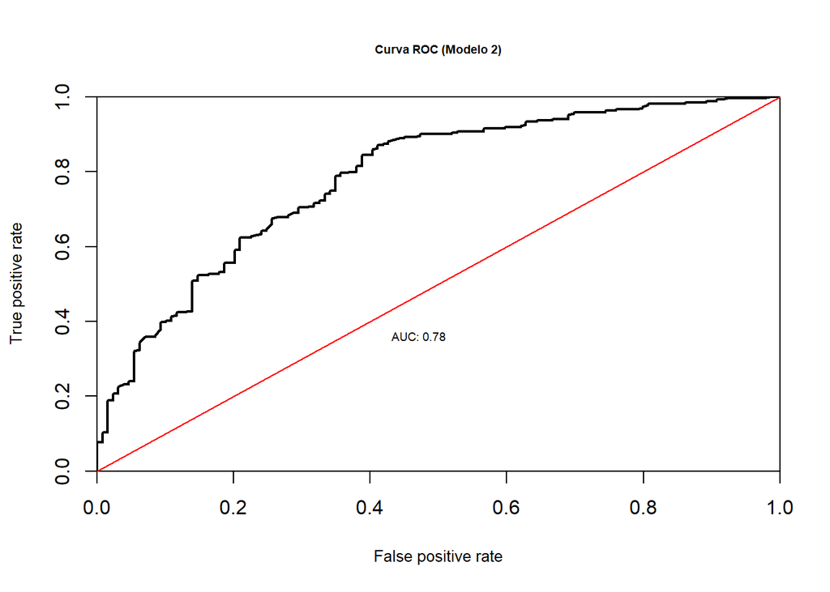

```r
previsao_teste_2 <- predict(modelo_ML_logistic_2, test_data, type = 'response')
previsao_teste_2 <- round(previsao_teste_2)

previsao_teste_2_data <- data.frame(previsao_teste_2, test_target)
colnames(previsao_teste_2_data) <- c('Previsão Nova','Target')

# Previsões do modelo de regressão logística 1
previsao_teste_modelo_2 <- predict(modelo_ML_logistic_2, test_data, type = 'response')
# previsao_teste_modelo_2 <- round(previsao_teste_modelo_2)

# Dataframe - previsão do modelo 2
# dataframe_previsao_modelo_2 <- data.frame(previsao_teste_modelo_2, test_target)
# colnames(dataframe_previsao_modelo_2) <- c('Previsão Nova','Target')
# View(dataframe_previsao_modelo_2)

# Repare na diferença entre a função predict e a função prediction
previsoes_finais_modelo_2 <- prediction(previsao_teste_modelo_2, test_target)

plot.roc.curve <- function(predictions, title.text){
  perf <- performance(predictions, "tpr", "fpr")
  plot(perf,col = "black",lty = 1, lwd = 2,
       main = title.text, cex.main = 0.6, cex.lab = 0.8,xaxs = "i", yaxs = "i")
  abline(0,1, col = "red")
  auc <- performance(predictions,"auc")
  auc <- unlist(slot(auc, "y.values"))
  auc <- round(auc,2)
  legend(0.4,0.4,legend = c(paste0("AUC: ",auc)), cex = 0.6, bty = "n", box.col = "white")
}

# Plot - quantidade de gráficos na paleta gráfica do R
plot.roc.curve(previsoes_finais_modelo_2, title.text = "Curva ROC (Modelo 2)")
```